# MRI Metrics and Losses

20.09.2021

1. [Symmetric difference](https://en.wikipedia.org/wiki/Symmetric_difference).
2. Alex P. Zijdenbos, Benoit M. Dawant, Richard A. Margolin, and Andrew C. Palmer. Morphometric Analysis of White Matter Lesions in MR Images: Method and Validation. IEEE Transactions on Medical Imaging, Vol. 13, No. 4, December 1994.
3. Jeroen Bertels, Tom Eelbode, Maxim Berman, Dirk Vandermeulen, Frederik Maes, Raf Bisschops, and Matthew B. Blaschko. Optimizing the Dice Score and Jaccard Index for Medical Image Segmentation: Theory & Practice. [arXiv:1911.01685](https://arxiv.org/abs/1911.01685) [cs.CV].

### R

1. [R Subsetting](https://adv-r.hadley.nz/subsetting.html) in Advanced R. See Section 4.5.1 Lookup tables (character subsetting).
2. [Pandoc: a universal document converter](https://pandoc.org/index.html).
   - [User’s Guide](https://pandoc.org/MANUAL.html).

## Notation & Remarks

1. $X∩Y$, $X∪Y$, $X∆Y$ – intersection, union, symmetric difference of X and Y.
2. $|X|$ – liczba voxeli / pixeli w obszarze X.
3. $A$, $B$ – segmented region by the first observer (KM, or KM<sub>1</sub> when intra) and by the second observer (MP, or KM<sub>2</sub> when intra).
4. $Ω$ – set of all voxels (or pixels).
5. Areas are measured in voxels [vx], pixels [px] or [cm<sup>2</sup>]
6. Metric and losses are dimensionless and frequently given in percentages [%].

## Base Areas

These areas suffice to compute all interobserver and intraobserver segmentation metric, losses.
$$|A|\quad |B|\quad |A∩B|$$
The areas of union and symmetric difference will be computed from base areas:
$$\begin{align}
|A∪B|& = |A| + |B| - |A∩B|\\
|A∆B|& = |A| + |B| - 2|A∩B|
\end{align}$$

## Metrics – Dice and Kappa

$$\begin{align}
{\rm D}(A,B)& = 2·\frac{|A∩B|}{|A| + |B|} ∈ [0, 1]\\
Κ(A,B)& = \frac{p_o - p_c}{1 - p_c} ∈ (-∞, 1]
\end{align}$$

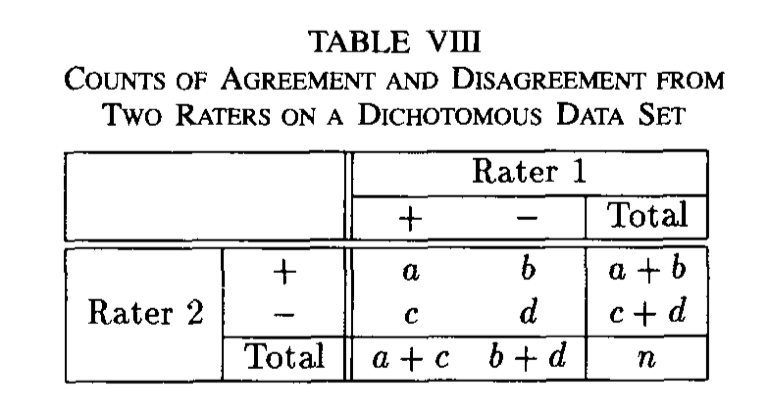

Alex P. Zijdenbos et al. p. 723.

## Jaccard distance

$$\begin{align}
{\rm J}(A,B)&= \frac{|A∩B|}{|A∪B|} = \frac{|A∩B|}{|A| + |B| - |A∩B|} ∈ [0, 1]\\
{\rm J}_d(A,B)&= 1 - {\rm J}(A,B) =
\frac{|A∆B|}{|A∪B|} = \frac{|A| + |B| - 2|A∩B|}{|A| + |B| - |A∩B|} ∈ [0, 1]
\end{align}$$

1. ${\rm J}(A,B)$ – Jaccard index
2. ${\rm J}_d(A,B)$ – Jaccard distance

## Properties, Theorems

Symmetric difference on measure spaces.
$$|μ(A) - μ(B)| \leq μ(A∆B)$$

Under the assumption $d \gg a$, $d \gg b$, $d \gg c$
$$\lim_{d\to\infty} Κ(A,B) = \frac{2a}{2a + b + c} = {\rm D}(A,B)$$
Relationships between the Jaccard index and the Dice score.
$${\rm J}(A,B) = \frac{{\rm D}(A,B)}{2 - {\rm D}(A,B)}
\quad\hbox{and}\quad
{\rm D}(A,B) = \frac{2{\rm J}(A,B)}{1 + {\rm J}(A,B)}$$